# Risk Factor Analysis

## Outcome Variable

**Outcome Variable:** haz

## Predictor Variables

**Intervention Variable:** exclfeed6

**Adjustment Set:**

unadjusted

## Stratifying Variables

The analysis was stratified on these variable(s):

- agecat
- studyid
- country

## Data Summary

| agecat | studyid | country | exclfeed6 | n_cell | n |
| --- | --- | --- | --- | --- | --- |
| Birth | CMC-V-BCS-2002 | INDIA | 1 | 7 | 7 |
| Birth | CMC-V-BCS-2002 | INDIA | 0 | 0 | 7 |
| Birth | EE | PAKISTAN | 1 | 38 | 42 |
| Birth | EE | PAKISTAN | 0 | 4 | 42 |
| Birth | GMS-Nepal | NEPAL | 1 | 419 | 563 |
| Birth | GMS-Nepal | NEPAL | 0 | 144 | 563 |
| Birth | IRC | INDIA | 1 | 0 | 14 |
| Birth | IRC | INDIA | 0 | 14 | 14 |
| Birth | Keneba | GAMBIA | 1 | 485 | 1403 |
| Birth | Keneba | GAMBIA | 0 | 918 | 1403 |
| Birth | MAL-ED | BANGLADESH | 1 | 31 | 205 |
| Birth | MAL-ED | BANGLADESH | 0 | 174 | 205 |
| Birth | MAL-ED | BRAZIL | 1 | 2 | 60 |
| Birth | MAL-ED | BRAZIL | 0 | 58 | 60 |
| Birth | MAL-ED | INDIA | 1 | 1 | 39 |
| Birth | MAL-ED | INDIA | 0 | 38 | 39 |
| Birth | MAL-ED | NEPAL | 1 | 2 | 24 |
| Birth | MAL-ED | NEPAL | 0 | 22 | 24 |
| Birth | MAL-ED | PERU | 1 | 2 | 213 |
| Birth | MAL-ED | PERU | 0 | 211 | 213 |
| Birth | MAL-ED | SOUTH AFRICA | 1 | 0 | 91 |
| Birth | MAL-ED | SOUTH AFRICA | 0 | 91 | 91 |
| Birth | MAL-ED | TANZANIA, UNITED REPUBLIC OF | 1 | 0 | 113 |
| Birth | MAL-ED | TANZANIA, UNITED REPUBLIC OF | 0 | 113 | 113 |
| Birth | PROVIDE | BANGLADESH | 1 | 159 | 539 |
| Birth | PROVIDE | BANGLADESH | 0 | 380 | 539 |
| Birth | SAS-CompFeed | INDIA | 1 | 346 | 364 |
| Birth | SAS-CompFeed | INDIA | 0 | 18 | 364 |
| 6 months | CMC-V-BCS-2002 | INDIA | 1 | 19 | 19 |
| 6 months | CMC-V-BCS-2002 | INDIA | 0 | 0 | 19 |

[output cut: 58 more lines]

The following strata were considered:

- agecat: 24 months, studyid: CMC-V-BCS-2002, country: INDIA
- agecat: 24 months, studyid: EE, country: PAKISTAN
- agecat: 24 months, studyid: GMS-Nepal, country: NEPAL
- agecat: 24 months, studyid: IRC, country: INDIA
- agecat: 24 months, studyid: Keneba, country: GAMBIA
- agecat: 24 months, studyid: LCNI-5, country: MALAWI
- agecat: 24 months, studyid: MAL-ED, country: BANGLADESH
- agecat: 24 months, studyid: MAL-ED, country: BRAZIL
- agecat: 24 months, studyid: MAL-ED, country: INDIA
- agecat: 24 months, studyid: MAL-ED, country: NEPAL
- agecat: 24 months, studyid: MAL-ED, country: PERU
- agecat: 24 months, studyid: MAL-ED, country: SOUTH AFRICA
- agecat: 24 months, studyid: MAL-ED, country: TANZANIA, UNITED REPUBLIC OF
- agecat: 24 months, studyid: PROVIDE, country: BANGLADESH
- agecat: 6 months, studyid: CMC-V-BCS-2002, country: INDIA
- agecat: 6 months, studyid: EE, country: PAKISTAN
- agecat: 6 months, studyid: GMS-Nepal, country: NEPAL
- agecat: 6 months, studyid: IRC, country: INDIA
- agecat: 6 months, studyid: Keneba, country: GAMBIA
- agecat: 6 months, studyid: LCNI-5, country: MALAWI
- agecat: 6 months, studyid: MAL-ED, country: BANGLADESH
- agecat: 6 months, studyid: MAL-ED, country: BRAZIL
- agecat: 6 months, studyid: MAL-ED, country: INDIA
- agecat: 6 months, studyid: MAL-ED, country: NEPAL
- agecat: 6 months, studyid: MAL-ED, country: PERU
- agecat: 6 months, studyid: MAL-ED, country: SOUTH AFRICA
- agecat: 6 months, studyid: MAL-ED, country: TANZANIA, UNITED REPUBLIC OF
- agecat: 6 months, studyid: PROVIDE, country: BANGLADESH
- agecat: 6 months, studyid: SAS-CompFeed, country: INDIA
- agecat: 6 months, studyid: SAS-FoodSuppl, country: INDIA
- agecat: Birth, studyid: CMC-V-BCS-2002, country: INDIA
- agecat: Birth, studyid: EE, country: PAKISTAN
- agecat: Birth, studyid: GMS-Nepal, country: NEPAL
- agecat: Birth, studyid: IRC, country: INDIA
- agecat: Birth, studyid: Keneba, country: GAMBIA
- agecat: Birth, studyid: MAL-ED, country: BANGLADESH
- agecat: Birth, studyid: MAL-ED, country: BRAZIL
- agecat: Birth, studyid: MAL-ED, country: INDIA
- agecat: Birth, studyid: MAL-ED, country: NEPAL
- agecat: Birth, studyid: MAL-ED, country: PERU
- agecat: Birth, studyid: MAL-ED, country: SOUTH AFRICA
- agecat: Birth, studyid: MAL-ED, country: TANZANIA, UNITED REPUBLIC OF
- agecat: Birth, studyid: PROVIDE, country: BANGLADESH
- agecat: Birth, studyid: SAS-CompFeed, country: INDIA

### Dropped Strata

Some strata were dropped due to rare outcomes:

- agecat: Birth, studyid: CMC-V-BCS-2002, country: INDIA
- agecat: Birth, studyid: EE, country: PAKISTAN
- agecat: Birth, studyid: IRC, country: INDIA
- agecat: Birth, studyid: MAL-ED, country: BRAZIL
- agecat: Birth, studyid: MAL-ED, country: INDIA
- agecat: Birth, studyid: MAL-ED, country: NEPAL
- agecat: Birth, studyid: MAL-ED, country: PERU
- agecat: Birth, studyid: MAL-ED, country: SOUTH AFRICA
- agecat: Birth, studyid: MAL-ED, country: TANZANIA, UNITED REPUBLIC OF
- agecat: 6 months, studyid: CMC-V-BCS-2002, country: INDIA
- agecat: 6 months, studyid: IRC, country: INDIA
- agecat: 6 months, studyid: MAL-ED, country: INDIA
- agecat: 6 months, studyid: MAL-ED, country: SOUTH AFRICA
- agecat: 6 months, studyid: MAL-ED, country: TANZANIA, UNITED REPUBLIC OF
- agecat: 6 months, studyid: SAS-FoodSuppl, country: INDIA
- agecat: 24 months, studyid: CMC-V-BCS-2002, country: INDIA
- agecat: 24 months, studyid: EE, country: PAKISTAN
- agecat: 24 months, studyid: IRC, country: INDIA
- agecat: 24 months, studyid: MAL-ED, country: INDIA
- agecat: 24 months, studyid: MAL-ED, country: PERU
- agecat: 24 months, studyid: MAL-ED, country: SOUTH AFRICA
- agecat: 24 months, studyid: MAL-ED, country: TANZANIA, UNITED REPUBLIC OF

## Methods Detail

We’re interested in the causal parameters $E[Y_a]$ for all values of $a \in \mathcal{A}$. These parameters represent the mean outcome if, possibly contrary to fact, we intervened to set all units to have $A=a$. Under the randomization and positivity assumptions, these are identified by the statistical parameters $\psi_a=E_W[E_{Y|A,W}(Y|A=a,W)]$. In addition, we’re interested in the mean of $Y$, $E[Y]$ under no intervention (the observed mean). We will estimate these parameters by using SuperLearner to fit the relevant likelihood factors – $E_{Y|A,W}(Y|A=a,W)$ and $p(A=a|W)$, and then updating our likelihood fit using a joint TMLE.

For unadjusted analyses ($W=\{\}$), initial likelihoods were estimated using Lrnr_glm to estimate the simple $E(Y|A)$ and Lrnr_mean to estimate $p(A)$. For adjusted analyses, a small library containing Lrnr_glmnet, Lrnr_xgboost, and Lrnr_mean was used.

Having estimated these parameters, we will then use the delta method to estimate relative risks and attributable risks relative to a prespecified baseline level of $A$.

# Results Detail

## Results Plots

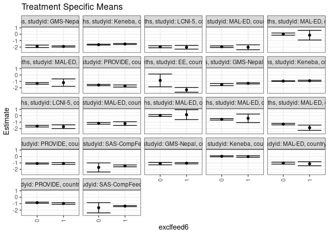

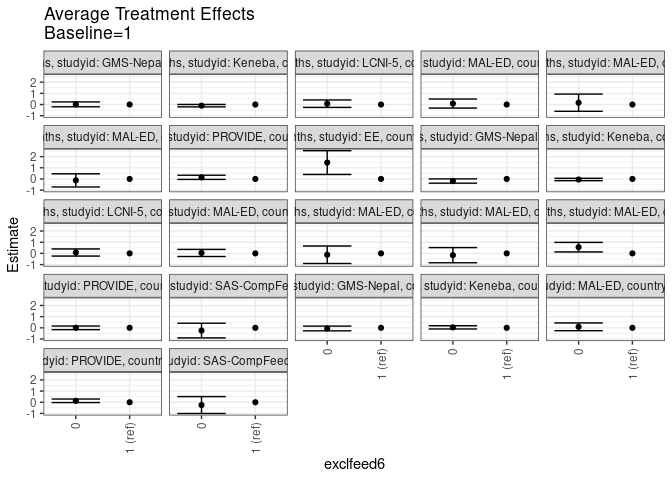

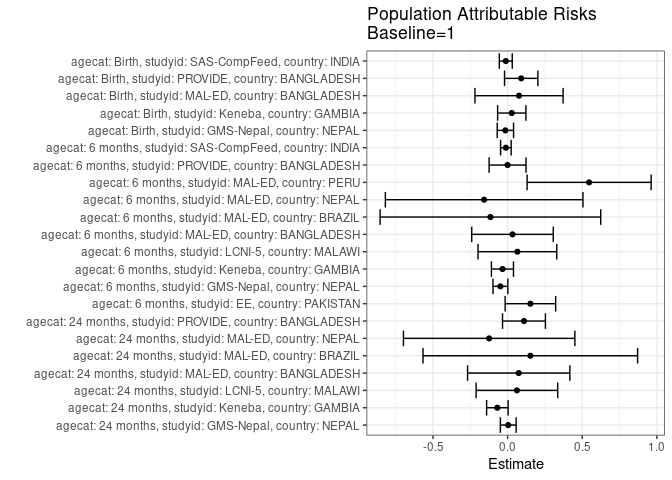

## Results Table

### Parameter: TSM

| agecat | studyid | country | intervention_level | baseline_level | estimate | ci_lower | ci_upper |
| --- | --- | --- | --- | --- | --- | --- | --- |
| Birth | GMS-Nepal | NEPAL | 1 | NA | -1.0491647 | -1.1485493 | -0.9497800 |
| Birth | GMS-Nepal | NEPAL | 0 | NA | -1.1076389 | -1.2968501 | -0.9184276 |
| Birth | Keneba | GAMBIA | 1 | NA | -0.0150722 | -0.1336922 | 0.1035478 |
| Birth | Keneba | GAMBIA | 0 | NA | 0.0272876 | -0.0557562 | 0.1103314 |
| Birth | MAL-ED | BANGLADESH | 1 | NA | -1.1293548 | -1.4416912 | -0.8170185 |
| Birth | MAL-ED | BANGLADESH | 0 | NA | -1.0394253 | -1.1925435 | -0.8863070 |
| Birth | PROVIDE | BANGLADESH | 1 | NA | -0.9760377 | -1.1050691 | -0.8470063 |
| Birth | PROVIDE | BANGLADESH | 0 | NA | -0.8470526 | -0.9384959 | -0.7556094 |
| Birth | SAS-CompFeed | INDIA | 1 | NA | -1.3813295 | -1.4669649 | -1.2956940 |
| Birth | SAS-CompFeed | INDIA | 0 | NA | -1.6316667 | -2.4310586 | -0.8322747 |
| 6 months | EE | PAKISTAN | 1 | NA | -2.3121318 | -2.6865239 | -1.9377397 |
| 6 months | EE | PAKISTAN | 0 | NA | -0.8473333 | -1.8424880 | 0.1478213 |
| 6 months | GMS-Nepal | NEPAL | 1 | NA | -1.3056486 | -1.3947532 | -1.2165440 |
| 6 months | GMS-Nepal | NEPAL | 0 | NA | -1.4933333 | -1.6620428 | -1.3246238 |
| 6 months | Keneba | GAMBIA | 1 | NA | -0.8984747 | -0.9872128 | -0.8097366 |
| 6 months | Keneba | GAMBIA | 0 | NA | -0.9484639 | -1.0075750 | -0.8893528 |
| 6 months | LCNI-5 | MALAWI | 1 | NA | -1.7051064 | -1.9955729 | -1.4146399 |
| 6 months | LCNI-5 | MALAWI | 0 | NA | -1.6259111 | -1.7571663 | -1.4946560 |
| 6 months | MAL-ED | BANGLADESH | 1 | NA | -1.2227273 | -1.5131856 | -0.9322689 |
| 6 months | MAL-ED | BANGLADESH | 0 | NA | -1.1846380 | -1.3154272 | -1.0538489 |
| 6 months | MAL-ED | BRAZIL | 1 | NA | 0.1629167 | -0.6076951 | 0.9335285 |
| 6 months | MAL-ED | BRAZIL | 0 | NA | 0.0405499 | -0.1046915 | 0.1857913 |
| 6 months | MAL-ED | NEPAL | 1 | NA | -0.4050000 | -1.0737079 | 0.2637079 |
| 6 months | MAL-ED | NEPAL | 0 | NA | -0.5658106 | -0.6826403 | -0.4489809 |
| 6 months | MAL-ED | PERU | 1 | NA | -1.8680000 | -2.2794681 | -1.4565319 |
| 6 months | MAL-ED | PERU | 0 | NA | -1.3117701 | -1.4224656 | -1.2010745 |
| 6 months | PROVIDE | BANGLADESH | 1 | NA | -1.0912766 | -1.2265269 | -0.9560263 |
| 6 months | PROVIDE | BANGLADESH | 0 | NA | -1.0918179 | -1.1797398 | -1.0038959 |
| 6 months | SAS-CompFeed | INDIA | 1 | NA | -1.4578628 | -1.6049871 | -1.3107385 |
| 6 months | SAS-CompFeed | INDIA | 0 | NA | -1.7063158 | -2.4149433 | -0.9976883 |
| 24 months | GMS-Nepal | NEPAL | 1 | NA | -1.9043914 | -2.0002013 | -1.8085814 |
| 24 months | GMS-Nepal | NEPAL | 0 | NA | -1.8871637 | -2.0828171 | -1.6915103 |
| 24 months | Keneba | GAMBIA | 1 | NA | -1.5187317 | -1.6046693 | -1.4327942 |
| 24 months | Keneba | GAMBIA | 0 | NA | -1.6231827 | -1.6901634 | -1.5562020 |
| 24 months | LCNI-5 | MALAWI | 1 | NA | -2.0273529 | -2.3204751 | -1.7342307 |
| 24 months | LCNI-5 | MALAWI | 0 | NA | -1.9514839 | -2.1097913 | -1.7931764 |
| 24 months | MAL-ED | BANGLADESH | 1 | NA | -2.0319355 | -2.4125437 | -1.6513273 |
| 24 months | MAL-ED | BANGLADESH | 0 | NA | -1.9443966 | -2.0791660 | -1.8096271 |
| 24 months | MAL-ED | BRAZIL | 1 | NA | -0.1459091 | -0.8952222 | 0.6034040 |
| 24 months | MAL-ED | BRAZIL | 0 | NA | 0.0166983 | -0.1559186 | 0.1893152 |
| 24 months | MAL-ED | NEPAL | 1 | NA | -1.1950000 | -1.7707330 | -0.6192670 |
| 24 months | MAL-ED | NEPAL | 0 | NA | -1.3216589 | -1.4457846 | -1.1975331 |
| 24 months | PROVIDE | BANGLADESH | 1 | NA | -1.7119708 | -1.8734594 | -1.5504822 |
| 24 months | PROVIDE | BANGLADESH | 0 | NA | -1.5683900 | -1.6651684 | -1.4716117 |

### Parameter: E(Y)

| agecat | studyid | country | intervention_level | baseline_level | estimate | ci_lower | ci_upper |
| --- | --- | --- | --- | --- | --- | --- | --- |
| Birth | GMS-Nepal | NEPAL | NA | NA | -1.0641208 | -1.1525364 | -0.9757052 |
| Birth | Keneba | GAMBIA | NA | NA | 0.0126443 | -0.0554367 | 0.0807254 |
| Birth | MAL-ED | BANGLADESH | NA | NA | -1.0530244 | -1.1913751 | -0.9146736 |
| Birth | PROVIDE | BANGLADESH | NA | NA | -0.8851020 | -0.9601332 | -0.8100709 |
| Birth | SAS-CompFeed | INDIA | NA | NA | -1.3937088 | -1.5095039 | -1.2779137 |
| 6 months | EE | PAKISTAN | NA | NA | -2.1595486 | -2.5331781 | -1.7859192 |
| 6 months | GMS-Nepal | NEPAL | NA | NA | -1.3540280 | -1.4334801 | -1.2745760 |
| 6 months | Keneba | GAMBIA | NA | NA | -0.9331108 | -0.9823173 | -0.8839043 |
| 6 months | LCNI-5 | MALAWI | NA | NA | -1.6395956 | -1.7592633 | -1.5199278 |
| 6 months | MAL-ED | BANGLADESH | NA | NA | -1.1900794 | -1.3096296 | -1.0705291 |
| 6 months | MAL-ED | BRAZIL | NA | NA | 0.0475758 | -0.0963508 | 0.1915023 |
| 6 months | MAL-ED | NEPAL | NA | NA | -0.5622370 | -0.6774081 | -0.4470660 |
| 6 months | MAL-ED | PERU | NA | NA | -1.3220326 | -1.4308168 | -1.2132484 |
| 6 months | PROVIDE | BANGLADESH | NA | NA | -1.0916915 | -1.1661176 | -1.0172654 |
| 6 months | SAS-CompFeed | INDIA | NA | NA | -1.4697236 | -1.6333919 | -1.3060553 |
| 24 months | GMS-Nepal | NEPAL | NA | NA | -1.9002128 | -1.9869255 | -1.8135001 |
| 24 months | Keneba | GAMBIA | NA | NA | -1.5876293 | -1.6406755 | -1.5345831 |
| 24 months | LCNI-5 | MALAWI | NA | NA | -1.9651323 | -2.1053230 | -1.8249415 |
| 24 months | MAL-ED | BANGLADESH | NA | NA | -1.9576341 | -2.0857597 | -1.8295086 |
| 24 months | MAL-ED | BRAZIL | NA | NA | 0.0061144 | -0.1625850 | 0.1748138 |
| 24 months | MAL-ED | NEPAL | NA | NA | -1.3187671 | -1.4406685 | -1.1968657 |
| 24 months | PROVIDE | BANGLADESH | NA | NA | -1.6024221 | -1.6857420 | -1.5191023 |

### Parameter: ATE

| agecat | studyid | country | intervention_level | baseline_level | estimate | ci_lower | ci_upper |
| --- | --- | --- | --- | --- | --- | --- | --- |
| Birth | GMS-Nepal | NEPAL | 1 | 1 | 0.0000000 | 0.0000000 | 0.0000000 |
| Birth | GMS-Nepal | NEPAL | 0 | 1 | -0.0584742 | -0.2721988 | 0.1552504 |
| Birth | Keneba | GAMBIA | 1 | 1 | 0.0000000 | 0.0000000 | 0.0000000 |
| Birth | Keneba | GAMBIA | 0 | 1 | 0.0423597 | -0.1024400 | 0.1871595 |
| Birth | MAL-ED | BANGLADESH | 1 | 1 | 0.0000000 | 0.0000000 | 0.0000000 |
| Birth | MAL-ED | BANGLADESH | 0 | 1 | 0.0899296 | -0.2579198 | 0.4377789 |
| Birth | PROVIDE | BANGLADESH | 1 | 1 | 0.0000000 | 0.0000000 | 0.0000000 |
| Birth | PROVIDE | BANGLADESH | 0 | 1 | 0.1289851 | -0.0291635 | 0.2871337 |
| Birth | SAS-CompFeed | INDIA | 1 | 1 | 0.0000000 | 0.0000000 | 0.0000000 |
| Birth | SAS-CompFeed | INDIA | 0 | 1 | -0.2503372 | -1.0066389 | 0.5059645 |
| 6 months | EE | PAKISTAN | 1 | 1 | 0.0000000 | 0.0000000 | 0.0000000 |
| 6 months | EE | PAKISTAN | 0 | 1 | 1.4647984 | 0.4015477 | 2.5280492 |
| 6 months | GMS-Nepal | NEPAL | 1 | 1 | 0.0000000 | 0.0000000 | 0.0000000 |
| 6 months | GMS-Nepal | NEPAL | 0 | 1 | -0.1876847 | -0.3784792 | 0.0031097 |
| 6 months | Keneba | GAMBIA | 1 | 1 | 0.0000000 | 0.0000000 | 0.0000000 |
| 6 months | Keneba | GAMBIA | 0 | 1 | -0.0499892 | -0.1566127 | 0.0566343 |
| 6 months | LCNI-5 | MALAWI | 1 | 1 | 0.0000000 | 0.0000000 | 0.0000000 |
| 6 months | LCNI-5 | MALAWI | 0 | 1 | 0.0791953 | -0.2395502 | 0.3979408 |
| 6 months | MAL-ED | BANGLADESH | 1 | 1 | 0.0000000 | 0.0000000 | 0.0000000 |
| 6 months | MAL-ED | BANGLADESH | 0 | 1 | 0.0380892 | -0.2804572 | 0.3566357 |
| 6 months | MAL-ED | BRAZIL | 1 | 1 | 0.0000000 | 0.0000000 | 0.0000000 |
| 6 months | MAL-ED | BRAZIL | 0 | 1 | -0.1223668 | -0.9065463 | 0.6618128 |
| 6 months | MAL-ED | NEPAL | 1 | 1 | 0.0000000 | 0.0000000 | 0.0000000 |
| 6 months | MAL-ED | NEPAL | 0 | 1 | -0.1608106 | -0.8396474 | 0.5180262 |
| 6 months | MAL-ED | PERU | 1 | 1 | 0.0000000 | 0.0000000 | 0.0000000 |
| 6 months | MAL-ED | PERU | 0 | 1 | 0.5562299 | 0.1301320 | 0.9823279 |
| 6 months | PROVIDE | BANGLADESH | 1 | 1 | 0.0000000 | 0.0000000 | 0.0000000 |
| 6 months | PROVIDE | BANGLADESH | 0 | 1 | -0.0005413 | -0.1618575 | 0.1607749 |
| 6 months | SAS-CompFeed | INDIA | 1 | 1 | 0.0000000 | 0.0000000 | 0.0000000 |
| 6 months | SAS-CompFeed | INDIA | 0 | 1 | -0.2484530 | -0.9061015 | 0.4091955 |
| 24 months | GMS-Nepal | NEPAL | 1 | 1 | 0.0000000 | 0.0000000 | 0.0000000 |
| 24 months | GMS-Nepal | NEPAL | 0 | 1 | 0.0172276 | -0.2006251 | 0.2350803 |
| 24 months | Keneba | GAMBIA | 1 | 1 | 0.0000000 | 0.0000000 | 0.0000000 |
| 24 months | Keneba | GAMBIA | 0 | 1 | -0.1044510 | -0.2134082 | 0.0045062 |
| 24 months | LCNI-5 | MALAWI | 1 | 1 | 0.0000000 | 0.0000000 | 0.0000000 |
| 24 months | LCNI-5 | MALAWI | 0 | 1 | 0.0758691 | -0.2572704 | 0.4090085 |
| 24 months | MAL-ED | BANGLADESH | 1 | 1 | 0.0000000 | 0.0000000 | 0.0000000 |
| 24 months | MAL-ED | BANGLADESH | 0 | 1 | 0.0875389 | -0.3162251 | 0.4913030 |
| 24 months | MAL-ED | BRAZIL | 1 | 1 | 0.0000000 | 0.0000000 | 0.0000000 |
| 24 months | MAL-ED | BRAZIL | 0 | 1 | 0.1626074 | -0.6063313 | 0.9315461 |
| 24 months | MAL-ED | NEPAL | 1 | 1 | 0.0000000 | 0.0000000 | 0.0000000 |
| 24 months | MAL-ED | NEPAL | 0 | 1 | -0.1266589 | -0.7156204 | 0.4623026 |
| 24 months | PROVIDE | BANGLADESH | 1 | 1 | 0.0000000 | 0.0000000 | 0.0000000 |
| 24 months | PROVIDE | BANGLADESH | 0 | 1 | 0.1435808 | -0.0446866 | 0.3318482 |

### Parameter: PAR

| agecat | studyid | country | intervention_level | baseline_level | estimate | ci_lower | ci_upper |
| --- | --- | --- | --- | --- | --- | --- | --- |
| Birth | GMS-Nepal | NEPAL | 1 | NA | -0.0149561 | -0.0696617 | 0.0397495 |
| Birth | Keneba | GAMBIA | 1 | NA | 0.0277165 | -0.0670336 | 0.1224666 |
| Birth | MAL-ED | BANGLADESH | 1 | NA | 0.0763304 | -0.2189504 | 0.3716113 |
| Birth | PROVIDE | BANGLADESH | 1 | NA | 0.0909357 | -0.0206713 | 0.2025426 |
| Birth | SAS-CompFeed | INDIA | 1 | NA | -0.0123793 | -0.0557043 | 0.0309456 |
| 6 months | EE | PAKISTAN | 1 | NA | 0.1525832 | -0.0166253 | 0.3217917 |
| 6 months | GMS-Nepal | NEPAL | 1 | NA | -0.0483794 | -0.0980402 | 0.0012813 |
| 6 months | Keneba | GAMBIA | 1 | NA | -0.0346361 | -0.1085198 | 0.0392476 |
| 6 months | LCNI-5 | MALAWI | 1 | NA | 0.0655108 | -0.1981815 | 0.3292031 |
| 6 months | MAL-ED | BANGLADESH | 1 | NA | 0.0326479 | -0.2403974 | 0.3056932 |
| 6 months | MAL-ED | BRAZIL | 1 | NA | -0.1153409 | -0.8545059 | 0.6238241 |
| 6 months | MAL-ED | NEPAL | 1 | NA | -0.1572370 | -0.8191102 | 0.5046361 |
| 6 months | MAL-ED | PERU | 1 | NA | 0.5459674 | 0.1304259 | 0.9615089 |
| 6 months | PROVIDE | BANGLADESH | 1 | NA | -0.0004149 | -0.1240729 | 0.1232430 |
| 6 months | SAS-CompFeed | INDIA | 1 | NA | -0.0118608 | -0.0472806 | 0.0235590 |
| 24 months | GMS-Nepal | NEPAL | 1 | NA | 0.0041786 | -0.0486665 | 0.0570237 |
| 24 months | Keneba | GAMBIA | 1 | NA | -0.0688976 | -0.1408109 | 0.0030157 |
| 24 months | LCNI-5 | MALAWI | 1 | NA | 0.0622207 | -0.2110207 | 0.3354620 |
| 24 months | MAL-ED | BANGLADESH | 1 | NA | 0.0743013 | -0.2684328 | 0.4170354 |
| 24 months | MAL-ED | BRAZIL | 1 | NA | 0.1520235 | -0.5668915 | 0.8709385 |
| 24 months | MAL-ED | NEPAL | 1 | NA | -0.1237671 | -0.6980101 | 0.4504758 |
| 24 months | PROVIDE | BANGLADESH | 1 | NA | 0.1095487 | -0.0341812 | 0.2532785 |